# California Red Sea Urchin

# Historical Simulation Plots

## Historical Time-Series

### Spawning Biomass

#### Depletion

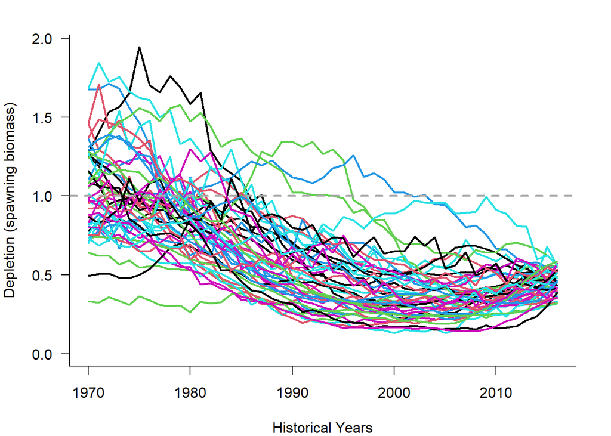

#### Absolute

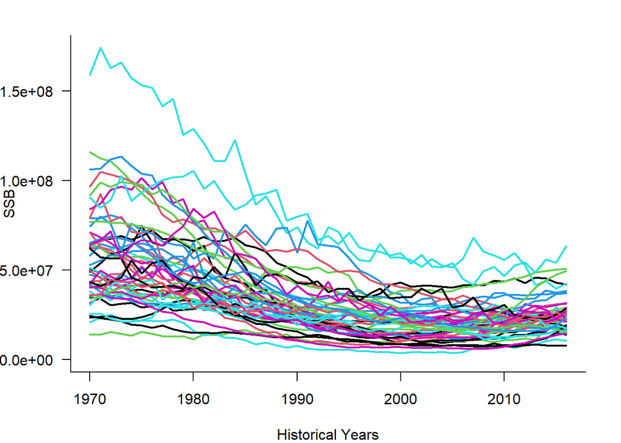

### Vulnerable Biomass

#### Depletion

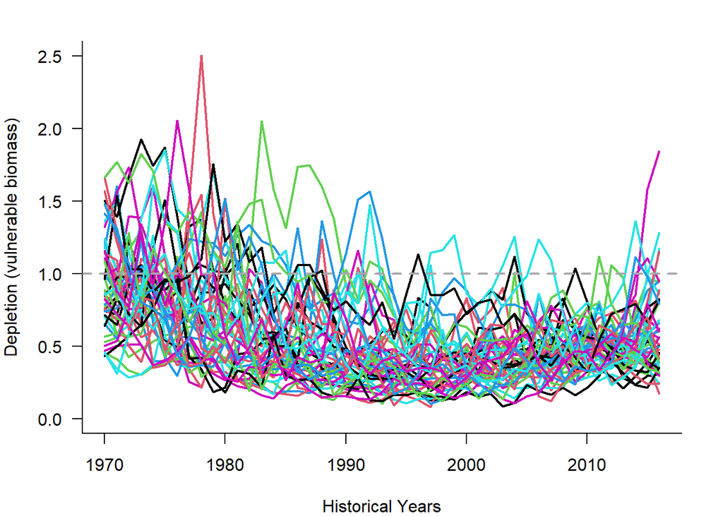

#### Absolute

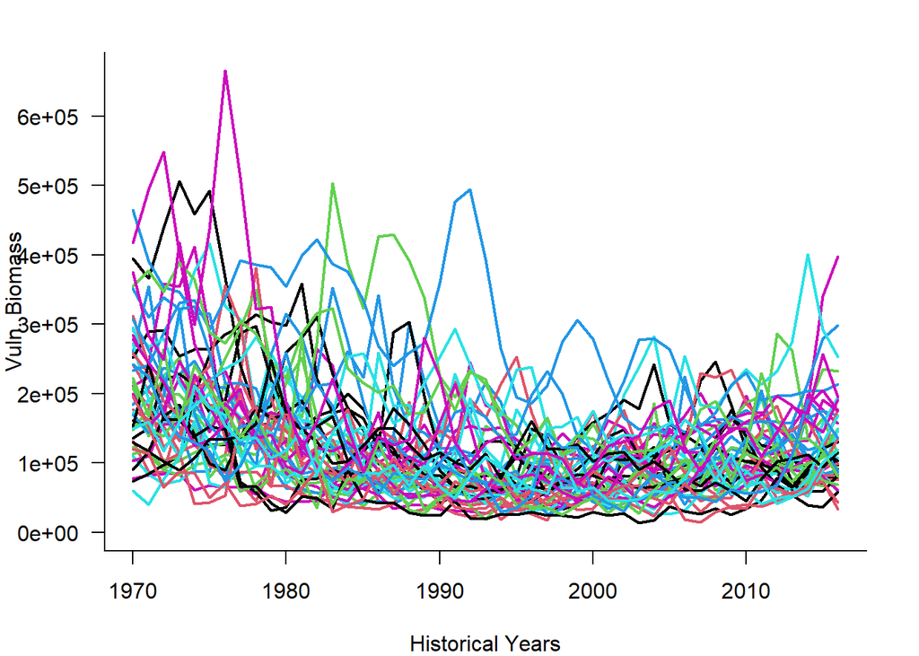

### Total Biomass

#### Depletion

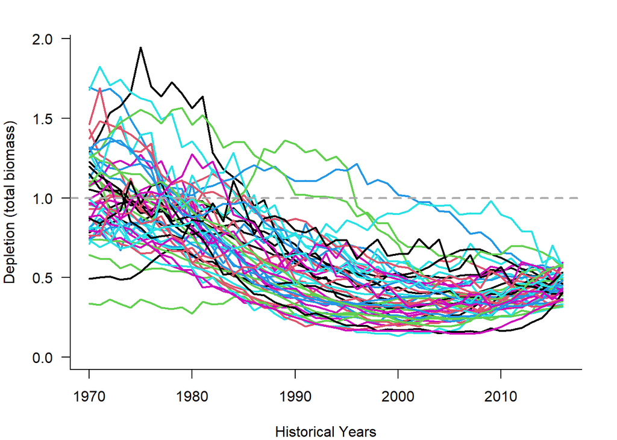

#### Absolute

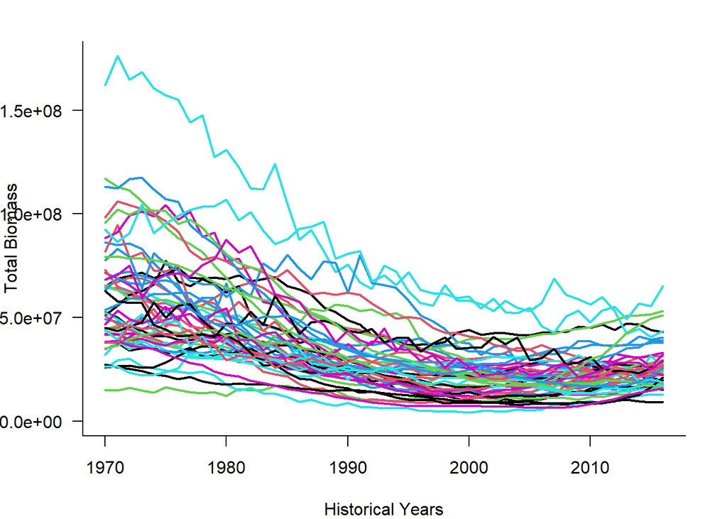

### Recruitment

#### Relative

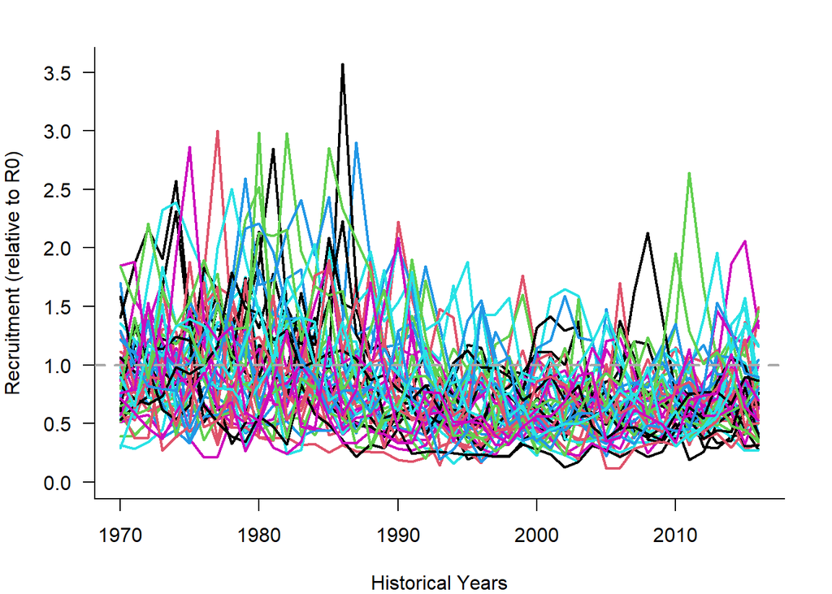

#### Absolute

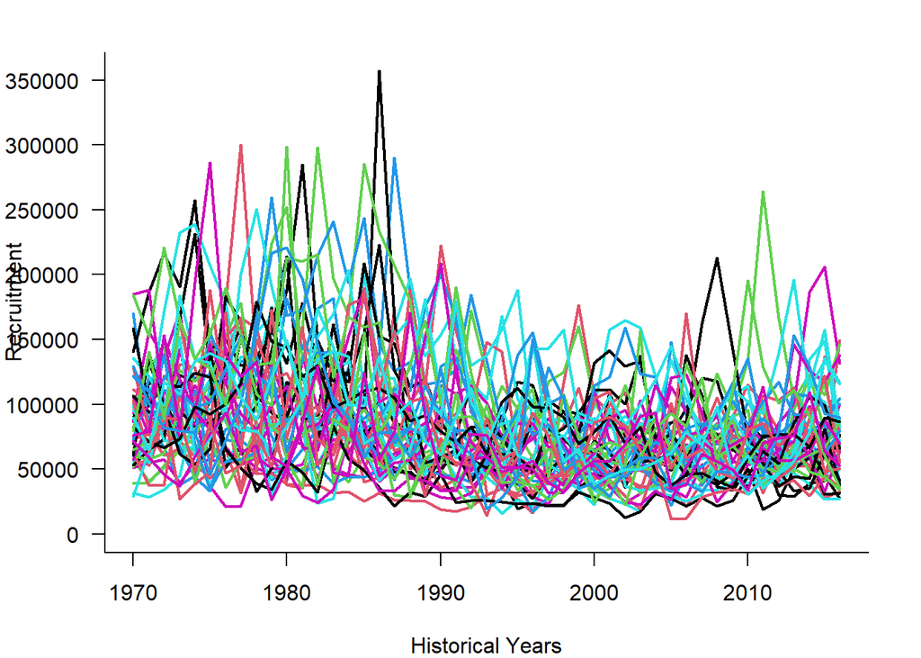

### Catch

#### Relative

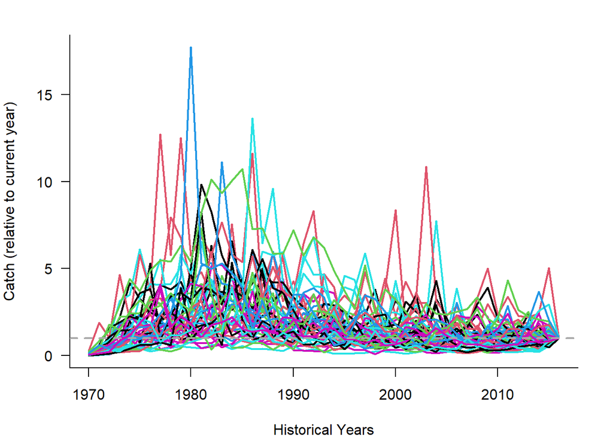

#### Absolute

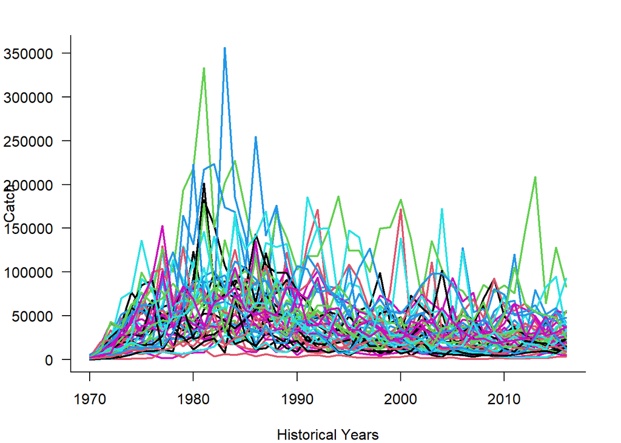

### Historical Fishing Mortality

#### Historical Time-Series

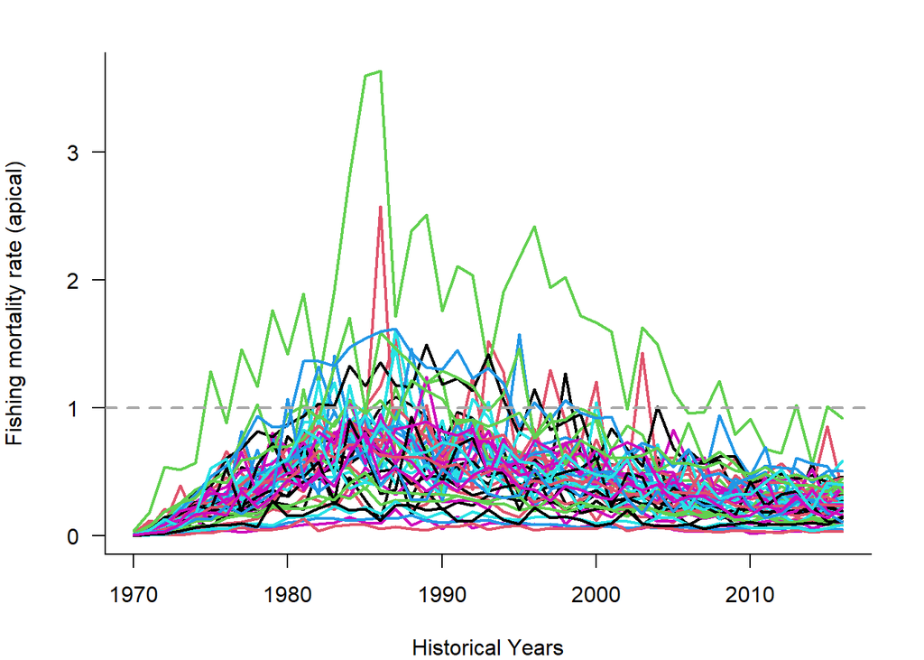

# References

Bernard, F.R., and Miller, D.C. 1973. Preliminary investigation on the Red Sea Urchin resources

of British Columbia (Strongylocentrotus franciscanus (Agassiz)).

Campbell, A. 1998. Catch, effort and quota estimates for the red sea urchin fishery in British

Columbia. In Invertebrate Working Papers reviewed by the Pacific Stock Assessment Review

Committee (PSARC) in 1995. Edited by B.J. Wadell, G.E. Gillespie, and L.C. Walthers.

Canadian Technical Reports Fisheries and Aquatic Science. pp. 83 – 109.

Ebert, T.A. 2008. Longevity and lack of senescence in the red sea urchin Strongylocentrotus

franciscanus. Exp. Gerontol. 43: 734–738. doi: 10.1016/j.exger.2008.04.015.

Ebert, T.A., Dixon, J.D., Schroeter, S.C., Kalvass, P.E., Richmond, N.T., Bradbury, W.A., and

Woodby, D. a. 1999. Growth and mortality of red sea urchins Strongylocentrotus franciscanus

across a latitudinal gradient. Mar. Ecol. Prog. Ser. 190: 189–209. doi: 10.3354/meps190189.

Ebert, T.A., and Russell, M.P. 1992. Growth and mortality estimates for red sea urchin

Strongylocentrotus franciscanus from San Nicolas Island, California. Mar. Ecol. Prog. Ser. 81:

31–41. doi: 10.3354/meps081031.

Ebert, T.A., and Southon, J.R. 2003. Red sea urchins (Strongylocentrotus franciscanus) can live

over 100 years: Confirmation with A-bomb 14 carbon. Fish. Bull. 101: 915–922.

Kalvass, P.E., and Hendrix, J.M. 1997. The California Red Sea Urchin, Strongylocentrotus

franciscanus, Fishery: Catch, Effort, and Management Trends. Mar. Fish. Rev. 59: 1–17.

Available from http://aquaticcommons.org/9820/.

Morgan, L.E., Botsford, L.W., Wing, S.R., and Smith, B.D. 2000. Spatial variability in growth and

mortality of the red sea urchin, Strongylocentrotus franciscanus, in northern California. Can. J.

Fish. Aquat. Sci. 57: 980–992. doi: 10.1139/cjfas-57-5-980.

Rogers-Bennett, L., Rogers, D.W., Bennet, W.A., and Ebert, T.A. 2003. Modeling red sea urchin

(Strongylocentrotus franciscanus) growth using six growth functions. Fish. Bull. 101: 614–626.